# PA1_template

Jorge Rodriguez

13 de noviembre de 2015

## Code to download and unzip the date and then load it into a dataframe

```r
library(lattice)
library(ggplot2)
setwd("/Users/rodrigblanco/Documents/Formacion/Coursera/05_ReproducibleResearch/Project1")
fileUrl <- "https://d396qusza40orc.cloudfront.net/repdata%2Fdata%2Factivity.zip"
download.file(fileUrl,"./repdata_data_activity.zip", method = "curl")
unzip("./repdata_data_activity.zip")
activity <- read.csv("./activity.csv",header = TRUE)
activity$date <- as.Date(activity$date)
```

## What is mean total number of steps taken per day?

Calculate the total number of steps taken per day

```r
stepsDate <- aggregate(activity$steps, list(date = activity$date), sum, na.rm=TRUE)
names(stepsDate) <- c("date","steps")
```

Make a histogram of the total number of steps taken each day

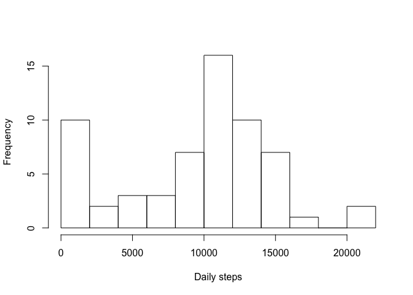

```r
hist(stepsDate$steps, main=" ", breaks=10, xlab="Daily steps")
```

Calculate and report the mean and median of the total number of steps taken per day

```r
mean(stepsDate$steps)
```

```
## [1] 9354.23
```

```r
median(stepsDate$steps)
```

```
## [1] 10395
```

## What is the average daily activity pattern?

Make a time series plot (i.e. type = “l”) of the 5-minute interval (x-axis) and the average number of steps taken, averaged across all days (y-axis)

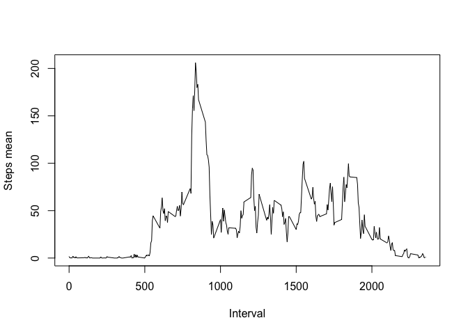

```r
stepsInterval <- aggregate(activity$steps, list(interval = activity$interval), mean, na.rm=TRUE)
names(stepsInterval) <- c("interval","steps")
with(stepsInterval,plot(interval, steps, type = "l",xlab = "Interval", ylab = "Steps mean"))
```

Which 5-minute interval, on average across all the days in the dataset, contains the maximum number of steps?

```r
stepsInterval[which.max(stepsInterval$steps), ]
```

```
##     interval    steps
## 104      835 206.1698
```